# Problem Set 03

### Data Filtering

A very common activity when you are analyzing data is to take subsets, be they subsets of rows or one or more columns (or both simultaneously). Gaining experience at this kind of filtering will make you much more efficient.

#### Activity

To give you some practice filtering, filter your data in the following ways using both:

1. base R functions
2. tidyverse functions

Verify your results match in each case. You do not need to save the resulting `data.frame`s.

1. All *Pardosa ramulosa*
2. All females of both species
3. Body mass and sex for *Nephila clavipes*
4. Rows 1-50 (either using base R or the `slice()` function from tidyverse [use `?slice` to view the help file])
5. Mass of the largest female (by mass) in each species
6. Male *Pardosa ramulosa* with body lengths less than 4 or greater than 6

```r
allpd_tdv <- SSD |>
  filter(Species == "Pardosa_ramulosa") #tidyverse

allpd_r <- subset(SSD, Species == "Pardosa_ramulosa")  #baseR

all.equal(allpd_tdv, allpd_r) #its saying not true but i believe it is
```

```
[1] "Attributes: < Names: 1 string mismatch >"
[2] "Attributes: < Length mismatch: comparison on first 2 components >"
[3] "Attributes: < Component \"class\": Lengths (4, 3) differ (string compare on first 3) >"
[4] "Attributes: < Component \"class\": 3 string mismatches >"
[5] "Attributes: < Component 2: target is externalptr, current is numeric >"
```

```r
#all females of both species

allf_tdv <- SSD |>
  filter(Sex == "F") #tidyverse

allf_r <- SSD[SSD$Sex == "F",] #baseR

all.equal(allf_r, allf_tdv) #its saying not true but i believe it is
```

```
[1] "Attributes: < Names: 1 string mismatch >"
[2] "Attributes: < Length mismatch: comparison on first 2 components >"
[3] "Attributes: < Component \"class\": Lengths (3, 4) differ (string compare on first 3) >"
[4] "Attributes: < Component \"class\": 3 string mismatches >"
[5] "Attributes: < Component 2: Modes: numeric, externalptr >"
[6] "Attributes: < Component 2: Lengths: 100, 1 >"
[7] "Attributes: < Component 2: target is numeric, current is externalptr >"
```

```r
#Body mass and sex for Nephila clavipes

bm_s_nc_tdv <- SSD |>
  filter(Species == "Nephila_clavipes") |>
  select(Species, BodyMass, Sex) #tidyverse

bm_s_nc_r<- SSD[SSD$Species=="Nephila_clavipes", c("Species","BodyMass", "Sex")] #baseR

all.equal(bm_s_nc_r, bm_s_nc_tdv) #its saying not true but i believe it is
```

```
[1] TRUE
```

```r
#Selcting rows 1-50 (this is not showing up as equal )

SSD_1_thru_50_tdv <- SSD |>
  slice(1:50) #TidyVerse

SSD_row_1_thru_50_br <-
  SSD[1:50, ]

all.equal(SSD_1_thru_50_tdv, SSD_row_1_thru_50_br)
```

```
[1] "Attributes: < Names: 1 string mismatch >"
[2] "Attributes: < Length mismatch: comparison on first 2 components >"
[3] "Attributes: < Component \"class\": Lengths (4, 3) differ (string compare on first 3) >"
[4] "Attributes: < Component \"class\": 3 string mismatches >"
[5] "Attributes: < Component 2: target is externalptr, current is numeric >"
```

```r
#largest female in both species

lf_tdv <- SSD |>
  group_by(Species) |>
  filter(Sex == "F") |>
  slice_max(BodyMass)

lf_r <- tapply(SSD$BodyMass,
               SSD$Species,
               FUN = max, #function max applied to multiple things
               na.rm = TRUE) # used google ai answers to help find out a way to this one.

print(lf_r)
```

```
Nephila_clavipes Pardosa_ramulosa
        1283.280            0.876
```

```r
# Male *Pardosa ramulosa* with body lengths less than 4 or greater than 6

mbl_tdv <- SSD |>
  filter(Sex == "M", Species == "Pardosa_ramulosa") |>
  filter( BodyLength < 4 | BodyLength > 6 ) #tidyverse

mbl_r <- SSD_pd_M_bl_r <- SSD[SSD$Sex == "M" &
                       SSD$Species == "Pardosa_ramulosa" &
                       (SSD$BodyLength < 4  | SSD$BodyLength  > 6), ] #BaseR#baseR

all.equal(mbl_r, mbl_tdv) #its saying not true but i believe it is
```

```
[1] "Attributes: < Names: 1 string mismatch >"
[2] "Attributes: < Length mismatch: comparison on first 2 components >"
[3] "Attributes: < Component \"class\": Lengths (3, 4) differ (string compare on first 3) >"
[4] "Attributes: < Component \"class\": 3 string mismatches >"
[5] "Attributes: < Component 2: Modes: numeric, externalptr >"
[6] "Attributes: < Component 2: Lengths: 22, 1 >"
[7] "Attributes: < Component 2: target is numeric, current is externalptr >"
```

```r
ssd1_50_tdv <- SSD|>slice(1:50) #tidyverse

ssd1_50_r <- SSD[1:50,] #baseR

all.equal(ssd1_50_r, ssd1_50_tdv)
```

```
[1] "Attributes: < Names: 1 string mismatch >"
[2] "Attributes: < Length mismatch: comparison on first 2 components >"
[3] "Attributes: < Component \"class\": Lengths (3, 4) differ (string compare on first 3) >"
[4] "Attributes: < Component \"class\": 3 string mismatches >"
[5] "Attributes: < Component 2: Modes: numeric, externalptr >"
[6] "Attributes: < Component 2: Lengths: 50, 1 >"
[7] "Attributes: < Component 2: target is numeric, current is externalptr >"
```

### Plotting Histograms

To start looking at sexual size dimorphism, we will make some histograms. Histograms are the easiest method to visualize univariate data.

#### Activity

Start with a histogram of body length overall. Follow the code in the lectures if you want to.

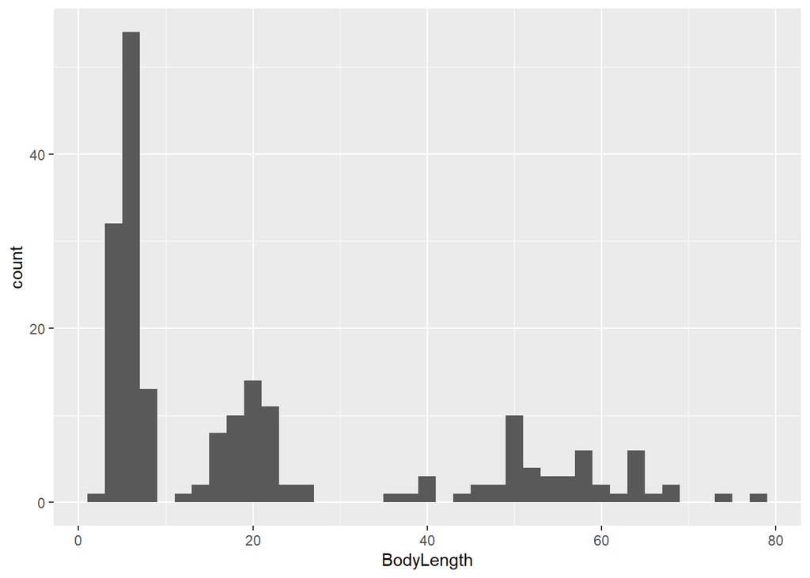

```r
SSD |>
  ggplot() +
  geom_histogram(aes(x=BodyLength), binwidth = 2)
```

There are some obvious groupings here, but we don’t know which species or sex the clusters represent. We need to separate both species and sex. One approach is to make a plot for each species with `fill` coding for sex (this is analogous to using color, but works with histograms). Try this.

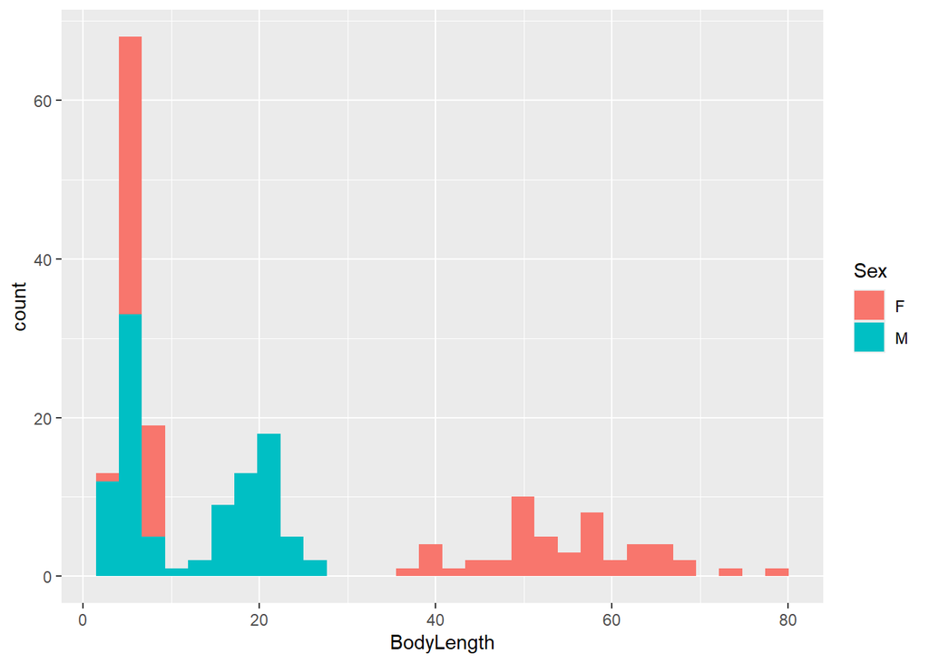

```r
SSD |>
  ggplot() +
  geom_histogram(aes(x=BodyLength, fill = Sex, binwidth = 2))
```

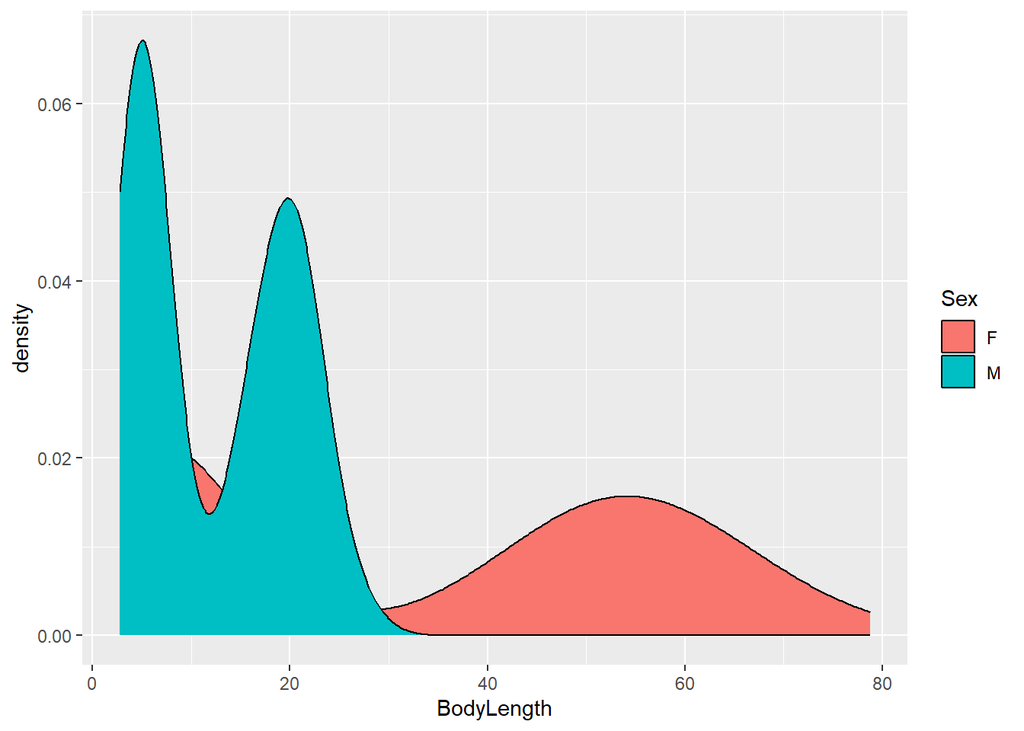

```r
SSD |>
  ggplot() +
  geom_density(aes(x=BodyLength, fill = Sex))
```

We could also visualize all groups with `facet_grid()`. Here is an example:

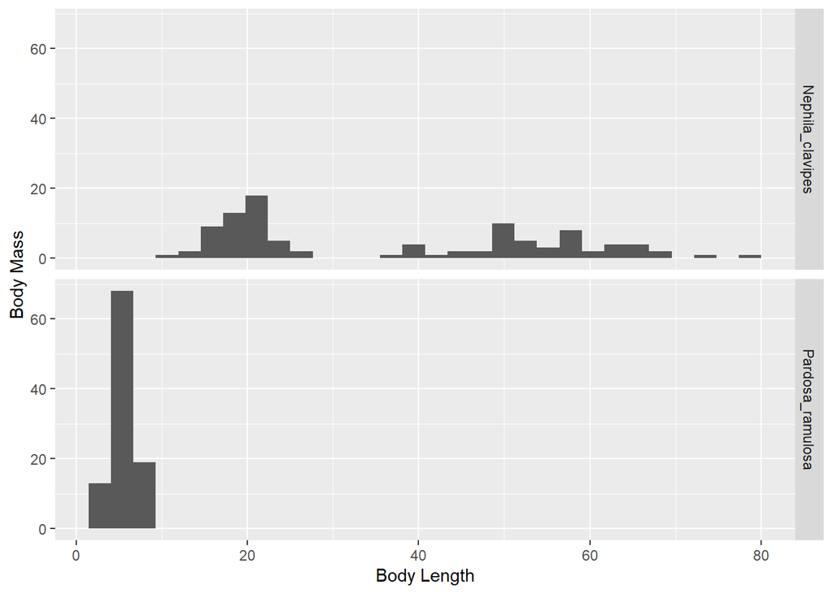

```r
SSD |>
ggplot(aes(x = BodyLength)) +
  geom_histogram() +
  facet_grid(Species ~ .) +
  labs(x = "Body Length", y = "Body Mass")
```

`facet_grid()` can take 1 or two arguments. The argument before `~` splits by rows, and after `~` splits by columns. If you only want one or the other use `.`. See the lecture slides for an example.

With this you can clearly see SSD in *Nephila* but not in *Pardosa*.

### Scatterplot

You might be interested in the relationship between body length and body mass. Scatterplots are the most common way to visualize such *bivariate* relationships.

#### Activity

Create a scatterplot of body length and body mass. Use color to show `Sex` and facet by `Species.` Put body length on the x-axis. Add axis labels, but don’t worry about units for now.

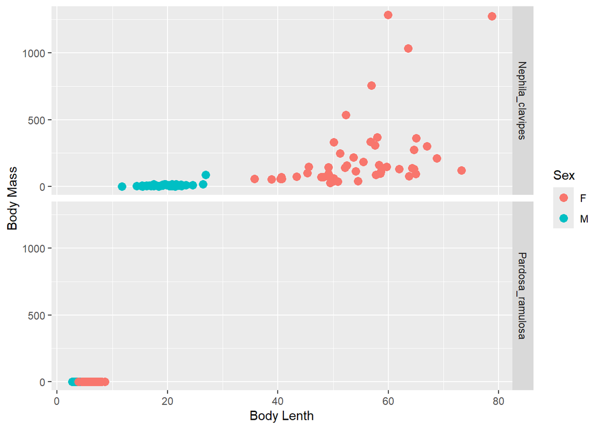

```r
SSD |>
  ggplot(aes(x=BodyLength, y=BodyMass, color=Sex)) +
  geom_point(size = 3) +
  facet_grid(Species~.) +
  labs(x = "Body Lenth", y= "Body Mass")
```

Describe the patterns you observe. Do you think this is a useful visualization? Why or why not?

Because body length and body mass are related by an exponential power, if we take advantage of the math of logarithms and log-transform the data, that will linearize the relationship. Ignoring the y-intercepts:

$$Mass \propto Length^b$$
$$\log(Mass) \propto b \log(Length)$$

Make two new variables that are the log10-transformations of body length and body mass using `mutate()`. Then plot the data again. Look at the help for `mutate` for hints. Then add new axis labels.

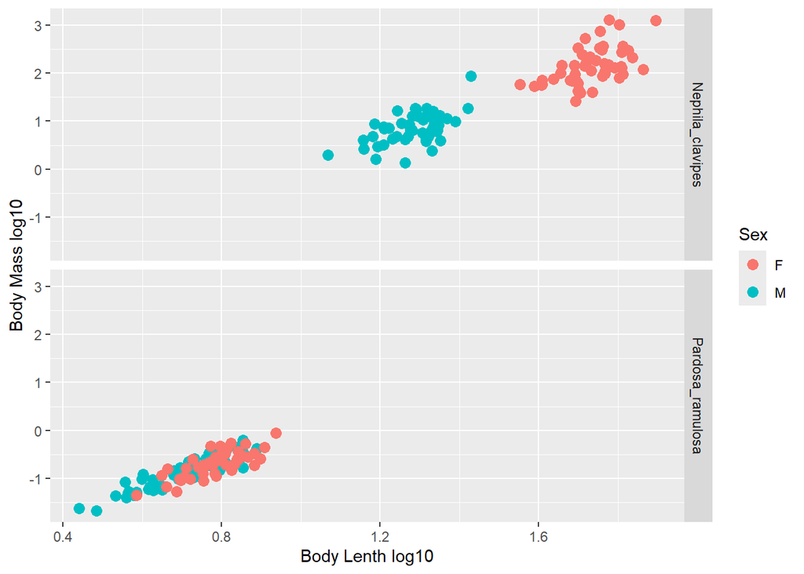

```r
SSD_log <- SSD |>
  mutate(BodyLength_log = log10(BodyLength),
         BodyMass_log = log10(BodyMass))

SSD_log|>
  ggplot(aes(x=BodyLength_log, y=BodyMass_log, color=Sex)) +
  geom_point(size = 3) +
  facet_grid(Species~.) +
  labs(x = "Body Lenth log10", y= "Body Mass log10")
```

What does this plot tell you? Do you think this is a more effective visualization of the data?

> Shows the linear relationship between the male and female differences

Now add lines of best fit (`geom_smooth()`) and transparency (`alpha`) to your points. View the [ggplot documentation](https://ggplot2.tidyverse.org/) for help with alpha.

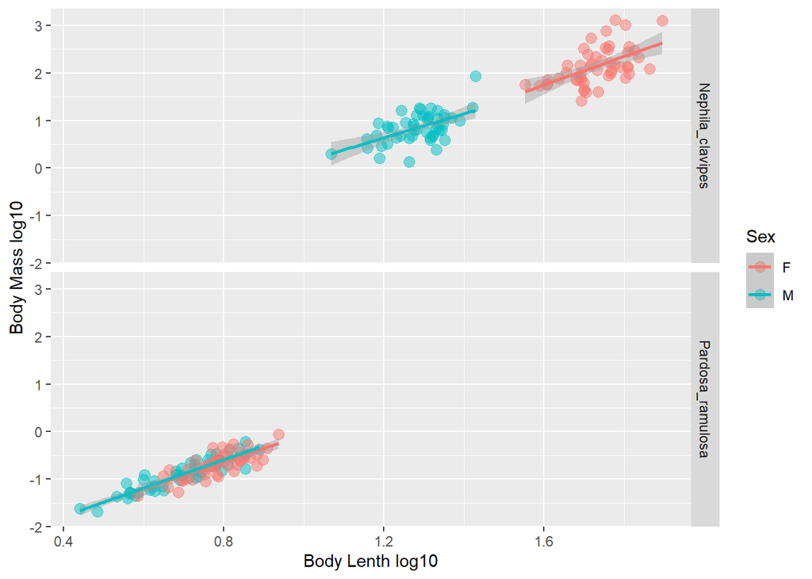

```r
SSD_log|>
  ggplot(aes(x=BodyLength_log, y=BodyMass_log, color=Sex)) +
  geom_point(size = 3, alpha = 0.5) +
  geom_smooth(formula = y~x, method = "lm") +
  facet_grid(Species~.) +
  labs(x = "Body Lenth log10", y= "Body Mass log10")
```

What do these regression lines tell you?

> The regression lines show us that most of the data points follow a relationship between longer spiders being heavier.

The process that you have just done, gradually building up a plot as part of exploratory data analysis, is what we recommend. Start with the most basic plot, like a scatterplot. Then add color for any groups and/or facetting. Notice patterns, and carry out data transformations. Add lines of best fit, etc. Until you get really fluent with ggplot, starting simple and building is the best approach.

## Rainout Experiment

In this next section, we will be practicing data manipulation and exploration. We will work with two files that contain data related to a “rainout” experiment. Changes in precipitation are commonly predicted with climate change, so rainout experiments are used to examine how different proposed future precipitation conditions (i.e., in our case high or low rain *reduction*) influences plant species composition and biomass.

The first dataset (`rainout_plots.csv`) describes plot-level data. This experiment contains 8 subplots per plot. Thus, these plot-level data contain plot and subplot identities, as well as only a single value per subplot for each of its variables (e.g., light availability, biomass), because these are collected at the subplot level.

We will also work with a dataset that contains information about species *within* each subplot called `rainout_plantspecies_presence.csv`. There will be multiple observations per subplot in this dataset, because the unique species in each subplot was recorded.

Let’s start with the plant composition data. Read in `rainout_plantspecies_presence.csv` and save it to an object called `comp`. Look at the structure of this tibble.

```r
comp <- read_csv("rainout_plantspecies_presence.csv")
str(comp)
```

```
spc_tbl_ [409 × 3] (S3: spec_tbl_df/tbl_df/tbl/data.frame)
 $ plot_no: num [1:409] 1 1 1 1 1 1 1 1 1 1 ...
 $ subplot: num [1:409] 1 1 1 2 2 2 2 2 2 3 ...
 $ species: chr [1:409] "poapra" "cortri" "andger" "poapra" ...
 - attr(*, "spec")=
  .. cols(
  ..   plot_no = col_double(),
  ..   subplot = col_double(),
  ..   species = col_character()
  .. )
 - attr(*, "problems")=<externalptr>
```

```r
glimpse(comp)
```

```
Rows: 409
Columns: 3
$ plot_no <dbl> 1, 1, 1, 1, 1, 1, 1, 1, 1, 1, 1, 1, 1, 1, 1, 1, 1, 1, 1, 1, 1,…
$ subplot <dbl> 1, 1, 1, 2, 2, 2, 2, 2, 2, 3, 3, 3, 3, 4, 4, 4, 4, 4, 5, 5, 5,…
$ species <chr> "poapra", "cortri", "andger", "poapra", "andger", "solcan", "a…
```

### Summarizing

One very important tool you will learn from the tidyverse is how to summarize your data. We will use the `summarize()` function quite a bit in this course, so let’s get some practice.

One thing we might want to know about is how many unique species are in each subplot within each plot. That way we can start to make predictions about how rain exclusion influences species richness. Using `group_by()` and `summarize()`, calculate the number of unique species per subplot within each plot in `comp`. Save the new object as `richness`, and also name the new variable `richness`.

Hint `(length(unique(<variable-of-interest>)))` will give you the number of rows that are unique within the groups you have set, which equates to the number of unique species, or richness, per subplot.

#### Activity

```r
richness <- comp |>
  group_by(plot_no) |>
  group_by(subplot) |>
  mutate(richness = length(unique(species))) #this is the one I made, and I'm not sure why it is like this

richness2 <- comp |>
  group_by(subplot, plot_no) |>
  mutate(richness = length(unique(species))) #why is this better than the one above

richness3 <- comp |>
  group_by(plot_no, subplot) |>
  mutate(richness = length(unique(species))) #this is the same as the one above
```

### Joining

One of the most common things you will do in your data cleaning and exploration stage is join datasets together. This will become especially important if you store your data as separate, smaller files. In our case, we need to join our `richness` object with our plot-level information so we can examine how richness changes with our two rainout treatments (e.g., high rain removal and low rain removal).

#### Activity

Read in the plot-level data, and save it to an object called `plot_ids`.

```r
plot_ids <- read_csv("rainout_plots.csv")
glimpse(plot_ids)
```

```
Rows: 96
Columns: 5
$ plot_no              <dbl> 1, 1, 1, 1, 1, 1, 1, 1, 2, 2, 2, 2, 2, 2, 2, 2, 8…
$ subplot              <dbl> 1, 2, 3, 4, 5, 6, 7, 8, 1, 2, 3, 4, 5, 6, 7, 8, 1…
$ rain_removal         <chr> "high", "high", "high", "high", "high", "high", "…
$ light_at_groundlevel <dbl> 90, 92, 102, 57, 129, 82, 151, 54, 91, 96, 117, 1…
$ biomass              <dbl> 531, 530, 623, 574, 75, 616, 526, 341, 426, 94, 5…
```

```r
glimpse(richness3)
```

```
Rows: 409
Columns: 4
Groups: plot_no, subplot [96]
$ plot_no  <dbl> 1, 1, 1, 1, 1, 1, 1, 1, 1, 1, 1, 1, 1, 1, 1, 1, 1, 1, 1, 1, 1…
$ subplot  <dbl> 1, 1, 1, 2, 2, 2, 2, 2, 2, 3, 3, 3, 3, 4, 4, 4, 4, 4, 5, 5, 5…
$ species  <chr> "poapra", "cortri", "andger", "poapra", "andger", "solcan", "…
$ richness <int> 3, 3, 3, 6, 6, 6, 6, 6, 6, 4, 4, 4, 4, 5, 5, 5, 5, 5, 5, 5, 5…
```

As we discussed in lecture, there are many different functions for joining in the tidyverse. We will focus on `left_join()` here because you can use this for most joining you need to do, and switch the order of the datasets you are joining depending on your need. For example, `left_join(d1, d2)` is the same as `right_join(d2, d1)`.

Join your plot level data to your species richness data using `left_join()`. You can save this as the same object that the richness was saved as previously, given this is the data you are building upon. Try doing this in two different ways, one where you specify the columns you want to join by, and one where you don’t and let `left_join()` pick the columns that automatically match. This should help you see the power of these joining functions.

```r
richnessdf <- left_join(richness3,plot_ids)
glimpse(richnessdf)
```

```
Rows: 409
Columns: 7
Groups: plot_no, subplot [96]
$ plot_no              <dbl> 1, 1, 1, 1, 1, 1, 1, 1, 1, 1, 1, 1, 1, 1, 1, 1, 1…
$ subplot              <dbl> 1, 1, 1, 2, 2, 2, 2, 2, 2, 3, 3, 3, 3, 4, 4, 4, 4…
$ species              <chr> "poapra", "cortri", "andger", "poapra", "andger",…
$ richness             <int> 3, 3, 3, 6, 6, 6, 6, 6, 6, 4, 4, 4, 4, 5, 5, 5, 5…
$ rain_removal         <chr> "high", "high", "high", "high", "high", "high", "…
$ light_at_groundlevel <dbl> 90, 90, 90, 92, 92, 92, 92, 92, 92, 102, 102, 102…
$ biomass              <dbl> 531, 531, 531, 530, 530, 530, 530, 530, 530, 623,…
```

```r
richness_sp <- left_join(richness3, plot_ids, by=join_by(plot_no, subplot))
glimpse(richness_sp)
```

```
Rows: 409
Columns: 7
Groups: plot_no, subplot [96]
$ plot_no              <dbl> 1, 1, 1, 1, 1, 1, 1, 1, 1, 1, 1, 1, 1, 1, 1, 1, 1…
$ subplot              <dbl> 1, 1, 1, 2, 2, 2, 2, 2, 2, 3, 3, 3, 3, 4, 4, 4, 4…
$ species              <chr> "poapra", "cortri", "andger", "poapra", "andger",…
$ richness             <int> 3, 3, 3, 6, 6, 6, 6, 6, 6, 4, 4, 4, 4, 5, 5, 5, 5…
$ rain_removal         <chr> "high", "high", "high", "high", "high", "high", "…
$ light_at_groundlevel <dbl> 90, 90, 90, 92, 92, 92, 92, 92, 92, 102, 102, 102…
$ biomass              <dbl> 531, 531, 531, 530, 530, 530, 530, 530, 530, 623,…
```

### More Summarizing

Along with the minimum, maximum, and range, two of the simplest and most common descriptive statistics are means and standard deviations.

#### Activity

Calculate the mean and standard deviation for species richness for each plot. Use `group_by()` and `summarize()`. Save this as a new object called `mean_richness`.

```r
mean_reachness <- richnessdf |>
  group_by(plot_no, species) |>
  summarize(avg_richness=mean(richness),
            sd_richness =sd(richness))
richness_sdm <- mean_richness2 <- richnessdf |>
  group_by(plot_no) |>
  summarize(mean(richness),sd(richness)) #good greif I have no idea what this one is doing

richness_sct <- left_join(richness_sdm, richnessdf) #richness data with rain removal info and then 12x3 into that
richness_sct <- richness_sct |>
  mutate(plot_no = as.factor(plot_no)) #changing plot number to factor so it can be called as factor
```

To visualize whether there are consistent differences in richness between rainout treatments, we will plot our data.

#### Activity

Create a scatterplot that shows how rain removal influences the average species richness using a scatter plot.

- Color the points by plot number in the `aes()`.
- Add transparency and/or jitter to make sure you can see all points clearly. - Because plots are a category, make sure it is being treated as a factor when you make your plot.
- Feel free to fix up the axis labels and choose a new color scheme if you wish.

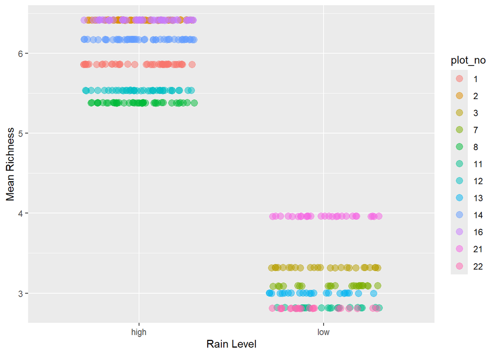

```r
richness_sct |>
  ggplot(aes(x=rain_removal, y=`mean(richness)`, color=plot_no)) +
  geom_point(size = 3,
             position = position_jitter(width = 0.3),
             alpha = 0.5) +
  labs(x="Rain Level", y = "Mean Richness")
```

With a scatterplot and this number of plots, it is difficult to see the trends per plot. Let’s try a boxplot instead. Use `geom_boxplot` and specify different colors for different plot numbers in the `aes()`.

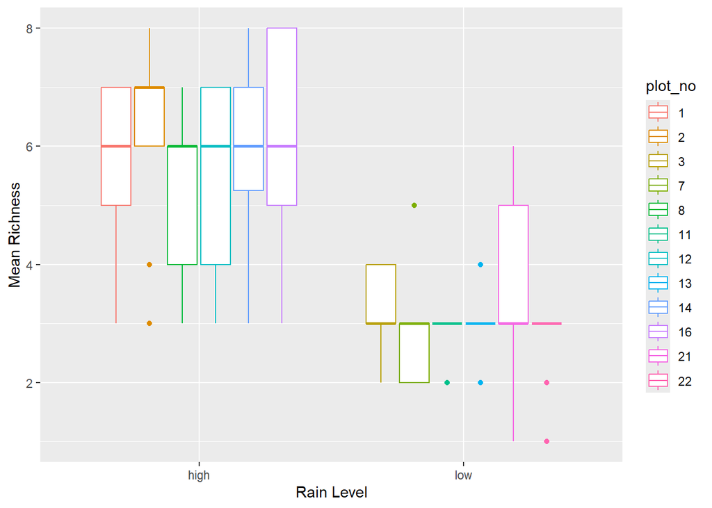

```r
richness_sct |>
  ggplot(aes(x=rain_removal, y=richness, color=plot_no)) +
  geom_boxplot() +
  labs(x="Rain Level", y = "Mean Richness")
```

Notice how setting `color =` in the aesthetics causes ggplot to split the data into groups *automatically* and apply separate lines or boxplots to those data. This is a very powerful feature of ggplot that makes it possible to generate very complex plots very easily. In contrast, imagine doing 12 separate linear regressions, adding them one by one to the plot and keeping track of all their different colors.

## AI Statement

Please indicate whether you used any generative AI tools to help you with this problem set and explain how you used these. An example of how to structure this statement is below. If you did not use generative AI, you can simply state: “I did not use AI for this problem set.”

Example statement structure: “I acknowledge the use of AI in completing this assignment and would like to provide a brief explanation of how I utilized AI, specifically [LLM], as a tool to support my work. For this assignment, I employed [LLM] to [describe the specific purpose or task]. To do so I crafted the following prompts: [List prompts used]”

> We used Gemini for number 6 of the filtering data to figure out how to get both less than 4 and greater than 6 in base R. We also asked it how to change a string into a vector.